# Cyclistic_bike_ride

Ritika Gupta

02/07/2021

```r
install.packages("tidyverse")
library(tidyverse)
```

```r
install.packages("ggplot2")
library(ggplot2)
install.packages("skimr")
library(skimr)
install.packages("janitor")
library(janitor)
```

## Step 1: Import data

One of the most common file types data analysts import into `R` is comma separated values files, or .csv files. The `tidyverse` library package `readr` has a number of functions for “reading in” or importing data, including .csv files and other external sources.

In the chunk below, use the `read_csv()` function to import data from the .csv files in the project folder called “Bike_trips_original_27_06_2021” and save it as a data frame called `bike_trip_2020_june_imported` . Similarly all the data for different months(June 2020-May 2021) are imported and saved in the respective data frame.

```r
bike_trip_2020_june_imported <- read_csv("~/Desktop/Case study/Bike_trips_original_27_06_2021/csv_files_2021_06_27_version1_original/2020_june.csv")
bike_trip_2020_july_imported <-read_csv("~/Desktop/Case study/Bike_trips_original_27_06_2021/csv_files_2021_06_27_version1_original/2020_july.csv")
bike_trip_2020_august_imported <-read_csv("~/Desktop/Case study/Bike_trips_original_27_06_2021/csv_files_2021_06_27_version1_original/2020_august.csv")
bike_trip_2020_sept_imported <-read_csv("~/Desktop/Case study/Bike_trips_original_27_06_2021/csv_files_2021_06_27_version1_original/2020_sept.csv")
bike_trip_2020_oct_imported <-read_csv("~/Desktop/Case study/Bike_trips_original_27_06_2021/csv_files_2021_06_27_version1_original/2020_oct.csv")
bike_trip_2020_nov_imported <-read_csv("~/Desktop/Case study/Bike_trips_original_27_06_2021/csv_files_2021_06_27_version1_original/2020_nov.csv")
bike_trip_2020_dec_imported <-read_csv("~/Desktop/Case study/Bike_trips_original_27_06_2021/csv_files_2021_06_27_version1_original/2020_dec.csv")
bike_trip_2021_jan_imported <-read_csv("~/Desktop/Case study/Bike_trips_original_27_06_2021/csv_files_2021_06_27_version1_original/2021_jan.csv")
bike_trip_2021_feb_imported <-read_csv("~/Desktop/Case study/Bike_trips_original_27_06_2021/csv_files_2021_06_27_version1_original/2021_feb.csv")
bike_trip_2021_march_imported <-read_csv("~/Desktop/Case study/Bike_trips_original_27_06_2021/csv_files_2021_06_27_version1_original/2021_march.csv")
bike_trip_2021_april_imported <-read_csv("~/Desktop/Case study/Bike_trips_original_27_06_2021/csv_files_2021_06_27_version1_original/2021_april.csv")
bike_trip_2021_may_imported <-read_csv("~/Desktop/Case study/Bike_trips_original_27_06_2021/csv_files_2021_06_27_version1_original/2021_may.csv")
```

## Step 2: Inspect & clean data

Next we are using the `head()` function, which returns the columns and first several rows of data. Check out the `head()` function by running the chunk below:

```r
head(bike_trip_2020_june_imported)
```

```
## # A tibble: 6 x 13
##   ride_id rideable_type started_at          ended_at            start_station_n…
##   <chr>   <chr>         <dttm>              <dttm>              <chr>
## 1 8CD5DE… docked_bike   2020-06-13 23:24:48 2020-06-13 23:36:55 Wilton Ave & Be…
## 2 9A191E… docked_bike   2020-06-26 07:26:10 2020-06-26 07:31:58 Federal St & Po…
## 3 F37D14… docked_bike   2020-06-23 17:12:41 2020-06-23 17:21:14 Daley Center Pl…
## 4 C41237… docked_bike   2020-06-20 01:09:35 2020-06-20 01:28:24 Broadway & Corn…
## 5 4B51B3… docked_bike   2020-06-25 16:59:25 2020-06-25 17:08:48 Sheffield Ave &…
## 6 D50DF2… docked_bike   2020-06-17 18:07:18 2020-06-17 18:18:14 Sheffield Ave &…
## # … with 8 more variables: start_station_id <dbl>, end_station_name <chr>,
## #   end_station_id <dbl>, start_lat <dbl>, start_lng <dbl>, end_lat <dbl>,
## #   end_lng <dbl>, member_casual <chr>
```

```r
head(bike_trip_2020_july_imported)
```

```
## # A tibble: 6 x 13
##   ride_id rideable_type started_at          ended_at            start_station_n…
##   <chr>   <chr>         <dttm>              <dttm>              <chr>
## 1 762198… docked_bike   2020-07-09 15:22:02 2020-07-09 15:25:52 Ritchie Ct & Ba…
## 2 BEC9C9… docked_bike   2020-07-24 23:56:30 2020-07-25 00:20:17 Halsted St & Ro…
## 3 D2FD8E… docked_bike   2020-07-08 19:49:07 2020-07-08 19:56:22 Lake Shore Dr &…
## 4 54AE59… docked_bike   2020-07-17 19:06:42 2020-07-17 19:27:38 LaSalle St & Il…
## 5 54025F… docked_bike   2020-07-04 10:39:57 2020-07-04 10:45:05 Lake Shore Dr &…
## 6 65636B… docked_bike   2020-07-28 16:33:03 2020-07-28 16:49:10 Fairbanks St & …
## # … with 8 more variables: start_station_id <dbl>, end_station_name <chr>,
## #   end_station_id <dbl>, start_lat <dbl>, start_lng <dbl>, end_lat <dbl>,
## #   end_lng <dbl>, member_casual <chr>
```

```r
head(bike_trip_2020_august_imported)
```

```
## # A tibble: 6 x 13
##   ride_id rideable_type started_at          ended_at            start_station_n…
##   <chr>   <chr>         <dttm>              <dttm>              <chr>
## 1 322BD2… docked_bike   2020-08-20 18:08:14 2020-08-20 18:17:51 Lake Shore Dr &…
## 2 2A3AEF… electric_bike 2020-08-27 18:46:04 2020-08-27 19:54:51 Michigan Ave & …
## 3 67DC1D… electric_bike 2020-08-26 19:44:14 2020-08-26 21:53:07 Columbus Dr & R…
## 4 C79FBB… electric_bike 2020-08-27 12:05:41 2020-08-27 12:53:45 Daley Center Pl…
## 5 13814D… electric_bike 2020-08-27 16:49:02 2020-08-27 16:59:49 Leavitt St & Di…
## 6 56349A… electric_bike 2020-08-27 17:26:23 2020-08-27 18:07:50 Leavitt St & Di…
## # … with 8 more variables: start_station_id <dbl>, end_station_name <chr>,
## #   end_station_id <dbl>, start_lat <dbl>, start_lng <dbl>, end_lat <dbl>,
## #   end_lng <dbl>, member_casual <chr>
```

```r
head(bike_trip_2020_sept_imported)
```

```
## # A tibble: 6 x 13
##   ride_id rideable_type started_at          ended_at            start_station_n…
##   <chr>   <chr>         <dttm>              <dttm>              <chr>
## 1 2B22BD… electric_bike 2020-09-17 14:27:11 2020-09-17 14:44:24 Michigan Ave & …
## 2 A7FB70… electric_bike 2020-09-17 15:07:31 2020-09-17 15:07:45 W Oakdale Ave &…
## 3 86057F… electric_bike 2020-09-17 15:09:04 2020-09-17 15:09:35 W Oakdale Ave &…
## 4 57F6DC… electric_bike 2020-09-17 18:10:46 2020-09-17 18:35:49 Ashland Ave & B…
## 5 B9C471… electric_bike 2020-09-17 15:16:13 2020-09-17 15:52:55 Fairbanks Ct & …
## 6 378BBC… electric_bike 2020-09-17 18:37:04 2020-09-17 19:23:28 Clark St & Armi…
## # … with 8 more variables: start_station_id <dbl>, end_station_name <chr>,
## #   end_station_id <dbl>, start_lat <dbl>, start_lng <dbl>, end_lat <dbl>,
## #   end_lng <dbl>, member_casual <chr>
```

```r
head(bike_trip_2020_oct_imported)
```

```
## # A tibble: 6 x 13
##   ride_id rideable_type started_at          ended_at            start_station_n…
##   <chr>   <chr>         <dttm>              <dttm>              <chr>
## 1 ACB6B4… electric_bike 2020-10-31 19:39:43 2020-10-31 19:57:12 Lakeview Ave & …
## 2 DF450C… electric_bike 2020-10-31 23:50:08 2020-11-01 00:04:16 Southport Ave &…
## 3 B6396B… electric_bike 2020-10-31 23:00:01 2020-10-31 23:08:22 Stony Island Av…
## 4 44A4AE… electric_bike 2020-10-31 22:16:43 2020-10-31 22:19:35 Clark St & Grac…
## 5 10B7DD… electric_bike 2020-10-31 19:38:19 2020-10-31 19:54:32 Southport Ave &…
## 6 DA6C37… electric_bike 2020-10-29 17:38:04 2020-10-29 17:45:43 Larrabee St & D…
## # … with 8 more variables: start_station_id <dbl>, end_station_name <chr>,
## #   end_station_id <dbl>, start_lat <dbl>, start_lng <dbl>, end_lat <dbl>,
## #   end_lng <dbl>, member_casual <chr>
```

```r
head(bike_trip_2020_nov_imported)
```

```
## # A tibble: 6 x 13
##   ride_id rideable_type started_at          ended_at            start_station_n…
##   <chr>   <chr>         <dttm>              <dttm>              <chr>
## 1 BD0A6F… electric_bike 2020-11-01 13:36:00 2020-11-01 13:45:40 Dearborn St & E…
## 2 96A7A7… electric_bike 2020-11-01 10:03:26 2020-11-01 10:14:45 Franklin St & I…
## 3 C61526… electric_bike 2020-11-01 00:34:05 2020-11-01 01:03:06 Lake Shore Dr &…
## 4 E533E8… electric_bike 2020-11-01 00:45:16 2020-11-01 00:54:31 Leavitt St & Ch…
## 5 1C9F4E… electric_bike 2020-11-01 15:43:25 2020-11-01 16:16:52 Buckingham Foun…
## 6 725958… electric_bike 2020-11-14 15:55:17 2020-11-14 16:44:38 Wabash Ave & 16…
## # … with 8 more variables: start_station_id <dbl>, end_station_name <chr>,
## #   end_station_id <dbl>, start_lat <dbl>, start_lng <dbl>, end_lat <dbl>,
## #   end_lng <dbl>, member_casual <chr>
```

```r
head(bike_trip_2020_dec_imported)
```

```
## # A tibble: 6 x 13
##   ride_id rideable_type started_at          ended_at            start_station_n…
##   <chr>   <chr>         <dttm>              <dttm>              <chr>
## 1 70B6A9… classic_bike  2020-12-27 12:44:29 2020-12-27 12:55:06 Aberdeen St & J…
## 2 158A46… electric_bike 2020-12-18 17:37:15 2020-12-18 17:44:19 <NA>
## 3 526201… electric_bike 2020-12-15 15:04:33 2020-12-15 15:11:28 <NA>
## 4 BE1196… electric_bike 2020-12-15 15:54:18 2020-12-15 16:00:11 <NA>
## 5 69AF78… electric_bike 2020-12-22 12:08:17 2020-12-22 12:10:59 <NA>
## 6 C1DECC… electric_bike 2020-12-22 13:26:37 2020-12-22 13:34:50 <NA>
## # … with 8 more variables: start_station_id <chr>, end_station_name <chr>,
## #   end_station_id <chr>, start_lat <dbl>, start_lng <dbl>, end_lat <dbl>,
## #   end_lng <dbl>, member_casual <chr>
```

```r
head(bike_trip_2021_jan_imported)
```

```
## # A tibble: 6 x 13
##   ride_id rideable_type started_at          ended_at            start_station_n…
##   <chr>   <chr>         <dttm>              <dttm>              <chr>
## 1 E19E6F… electric_bike 2021-01-23 16:14:19 2021-01-23 16:24:44 California Ave …
## 2 DC88F2… electric_bike 2021-01-27 18:43:08 2021-01-27 18:47:12 California Ave …
## 3 EC45C9… electric_bike 2021-01-21 22:35:54 2021-01-21 22:37:14 California Ave …
## 4 4FA453… electric_bike 2021-01-07 13:31:13 2021-01-07 13:42:55 California Ave …
## 5 BE5E8E… electric_bike 2021-01-23 02:24:02 2021-01-23 02:24:45 California Ave …
## 6 5D8969… electric_bike 2021-01-09 14:24:07 2021-01-09 15:17:54 California Ave …
## # … with 8 more variables: start_station_id <chr>, end_station_name <chr>,
## #   end_station_id <chr>, start_lat <dbl>, start_lng <dbl>, end_lat <dbl>,
## #   end_lng <dbl>, member_casual <chr>
```

```r
head(bike_trip_2021_feb_imported)
```

```
## # A tibble: 6 x 13
##   ride_id rideable_type started_at          ended_at            start_station_n…
##   <chr>   <chr>         <dttm>              <dttm>              <chr>
## 1 89E7AA… classic_bike  2021-02-12 16:14:56 2021-02-12 16:21:43 Glenwood Ave & …
## 2 0FEFDE… classic_bike  2021-02-14 17:52:38 2021-02-14 18:12:09 Glenwood Ave & …
## 3 E6159D… electric_bike 2021-02-09 19:10:18 2021-02-09 19:19:10 Clark St & Lake…
## 4 B32D31… classic_bike  2021-02-02 17:49:41 2021-02-02 17:54:06 Wood St & Chica…
## 5 83E463… electric_bike 2021-02-23 15:07:23 2021-02-23 15:22:37 State St & 33rd…
## 6 BDAA7E… electric_bike 2021-02-24 15:43:33 2021-02-24 15:49:05 Fairbanks St & …
## # … with 8 more variables: start_station_id <chr>, end_station_name <chr>,
## #   end_station_id <chr>, start_lat <dbl>, start_lng <dbl>, end_lat <dbl>,
## #   end_lng <dbl>, member_casual <chr>
```

```r
head(bike_trip_2021_march_imported)
```

```
## # A tibble: 6 x 13
##   ride_id rideable_type started_at          ended_at            start_station_n…
##   <chr>   <chr>         <dttm>              <dttm>              <chr>
## 1 CFA86D… classic_bike  2021-03-16 08:32:30 2021-03-16 08:36:34 Humboldt Blvd &…
## 2 30D9DC… classic_bike  2021-03-28 01:26:28 2021-03-28 01:36:55 Humboldt Blvd &…
## 3 846D87… classic_bike  2021-03-11 21:17:29 2021-03-11 21:33:53 Shields Ave & 2…
## 4 994D05… classic_bike  2021-03-11 13:26:42 2021-03-11 13:55:41 Winthrop Ave & …
## 5 DF7464… classic_bike  2021-03-21 09:09:37 2021-03-21 09:27:33 Glenwood Ave & …
## 6 CEBA85… classic_bike  2021-03-20 11:08:47 2021-03-20 11:29:39 Glenwood Ave & …
## # … with 8 more variables: start_station_id <chr>, end_station_name <chr>,
## #   end_station_id <chr>, start_lat <dbl>, start_lng <dbl>, end_lat <dbl>,
## #   end_lng <dbl>, member_casual <chr>
```

```r
head(bike_trip_2021_april_imported)
```

```
## # A tibble: 6 x 13
##   ride_id rideable_type started_at          ended_at            start_station_n…
##   <chr>   <chr>         <dttm>              <dttm>              <chr>
## 1 6C992B… classic_bike  2021-04-12 18:25:36 2021-04-12 18:56:55 State St & Pear…
## 2 1E0145… docked_bike   2021-04-27 17:27:11 2021-04-27 18:31:29 Dorchester Ave …
## 3 E498E1… docked_bike   2021-04-03 12:42:45 2021-04-07 11:40:24 Loomis Blvd & 8…
## 4 188726… classic_bike  2021-04-17 09:17:42 2021-04-17 09:42:48 Honore St & Div…
## 5 C12354… docked_bike   2021-04-03 12:42:25 2021-04-03 14:13:42 Loomis Blvd & 8…
## 6 097E76… classic_bike  2021-04-25 18:43:18 2021-04-25 18:43:59 Clinton St & Po…
## # … with 8 more variables: start_station_id <chr>, end_station_name <chr>,
## #   end_station_id <chr>, start_lat <dbl>, start_lng <dbl>, end_lat <dbl>,
## #   end_lng <dbl>, member_casual <chr>
```

```r
head(bike_trip_2021_may_imported)
```

```
## # A tibble: 6 x 13
##   ride_id rideable_type started_at          ended_at            start_station_n…
##   <chr>   <chr>         <dttm>              <dttm>              <chr>
## 1 C809ED… electric_bike 2021-05-30 11:58:15 2021-05-30 12:10:39 <NA>
## 2 DD59FD… electric_bike 2021-05-30 11:29:14 2021-05-30 12:14:09 <NA>
## 3 0AB83C… electric_bike 2021-05-30 14:24:01 2021-05-30 14:25:13 <NA>
## 4 7881AC… electric_bike 2021-05-30 14:25:51 2021-05-30 14:41:04 <NA>
## 5 853FA7… electric_bike 2021-05-30 18:15:39 2021-05-30 18:22:32 <NA>
## 6 F5E63D… electric_bike 2021-05-30 11:33:41 2021-05-30 11:57:17 <NA>
## # … with 8 more variables: start_station_id <chr>, end_station_name <chr>,
## #   end_station_id <chr>, start_lat <dbl>, start_lng <dbl>, end_lat <dbl>,
## #   end_lng <dbl>, member_casual <chr>
```

In addition to `head()` we are using ‘str()’ function to summarize or preview your data frame. For example, the `str()`function will provide summaries of each column in your data arranged horizontally.

```r
str(bike_trip_2020_june_imported)
```

```
## spec_tbl_df [343,005 × 13] (S3: spec_tbl_df/tbl_df/tbl/data.frame)
##  $ ride_id           : chr [1:343005] "8CD5DE2C2B6C4CFC" "9A191EB2C751D85D" "F37D14B0B5659BCF" "C41237B506E85FA1" ...
##  $ rideable_type     : chr [1:343005] "docked_bike" "docked_bike" "docked_bike" "docked_bike" ...
##  $ started_at        : POSIXct[1:343005], format: "2020-06-13 23:24:48" "2020-06-26 07:26:10" ...
##  $ ended_at          : POSIXct[1:343005], format: "2020-06-13 23:36:55" "2020-06-26 07:31:58" ...
##  $ start_station_name: chr [1:343005] "Wilton Ave & Belmont Ave" "Federal St & Polk St" "Daley Center Plaza" "Broadway & Cornelia Ave" ...
##  $ start_station_id  : num [1:343005] 117 41 81 303 327 327 41 115 338 84 ...
##  $ end_station_name  : chr [1:343005] "Damen Ave & Clybourn Ave" "Daley Center Plaza" "State St & Harrison St" "Broadway & Berwyn Ave" ...
##  $ end_station_id    : num [1:343005] 163 81 5 294 117 117 81 303 164 53 ...
##  $ start_lat         : num [1:343005] 41.9 41.9 41.9 41.9 41.9 ...
##  $ start_lng         : num [1:343005] -87.7 -87.6 -87.6 -87.6 -87.7 ...
##  $ end_lat           : num [1:343005] 41.9 41.9 41.9 42 41.9 ...
##  $ end_lng           : num [1:343005] -87.7 -87.6 -87.6 -87.7 -87.7 ...
##  $ member_casual     : chr [1:343005] "casual" "member" "member" "casual" ...
##  - attr(*, "spec")=
##   .. cols(
##   ..   ride_id = col_character(),
##   ..   rideable_type = col_character(),
##   ..   started_at = col_datetime(format = ""),
##   ..   ended_at = col_datetime(format = ""),
##   ..   start_station_name = col_character(),
##   ..   start_station_id = col_double(),
##   ..   end_station_name = col_character(),
##   ..   end_station_id = col_double(),
##   ..   start_lat = col_double(),
##   ..   start_lng = col_double(),
##   ..   end_lat = col_double(),
##   ..   end_lng = col_double(),
##   ..   member_casual = col_character()
##   .. )
```

```r
str(bike_trip_2020_july_imported)
```

```
## spec_tbl_df [551,480 × 13] (S3: spec_tbl_df/tbl_df/tbl/data.frame)
##  $ ride_id           : chr [1:551480] "762198876D69004D" "BEC9C9FBA0D4CF1B" "D2FD8EA432C77EC1" "54AE594E20B35881" ...
##  $ rideable_type     : chr [1:551480] "docked_bike" "docked_bike" "docked_bike" "docked_bike" ...
##  $ started_at        : POSIXct[1:551480], format: "2020-07-09 15:22:02" "2020-07-24 23:56:30" ...
##  $ ended_at          : POSIXct[1:551480], format: "2020-07-09 15:25:52" "2020-07-25 00:20:17" ...
##  $ start_station_name: chr [1:551480] "Ritchie Ct & Banks St" "Halsted St & Roscoe St" "Lake Shore Dr & Diversey Pkwy" "LaSalle St & Illinois St" ...
##  $ start_station_id  : num [1:551480] 180 299 329 181 268 635 113 211 176 31 ...
##  $ end_station_name  : chr [1:551480] "Wells St & Evergreen Ave" "Broadway & Ridge Ave" "Clark St & Wellington Ave" "Clark St & Armitage Ave" ...
##  $ end_station_id    : num [1:551480] 291 461 156 94 301 289 140 31 191 142 ...
##  $ start_lat         : num [1:551480] 41.9 41.9 41.9 41.9 41.9 ...
##  $ start_lng         : num [1:551480] -87.6 -87.6 -87.6 -87.6 -87.6 ...
##  $ end_lat           : num [1:551480] 41.9 42 41.9 41.9 41.9 ...
##  $ end_lng           : num [1:551480] -87.6 -87.7 -87.6 -87.6 -87.6 ...
##  $ member_casual     : chr [1:551480] "member" "member" "casual" "casual" ...
##  - attr(*, "spec")=
##   .. cols(
##   ..   ride_id = col_character(),
##   ..   rideable_type = col_character(),
##   ..   started_at = col_datetime(format = ""),
##   ..   ended_at = col_datetime(format = ""),
##   ..   start_station_name = col_character(),
##   ..   start_station_id = col_double(),
##   ..   end_station_name = col_character(),
##   ..   end_station_id = col_double(),
##   ..   start_lat = col_double(),
##   ..   start_lng = col_double(),
##   ..   end_lat = col_double(),
##   ..   end_lng = col_double(),
##   ..   member_casual = col_character()
##   .. )
```

```r
str(bike_trip_2020_august_imported)
```

```
## spec_tbl_df [622,361 × 13] (S3: spec_tbl_df/tbl_df/tbl/data.frame)
##  $ ride_id           : chr [1:622361] "322BD23D287743ED" "2A3AEF1AB9054D8B" "67DC1D133E8B5816" "C79FBBD412E578A7" ...
##  $ rideable_type     : chr [1:622361] "docked_bike" "electric_bike" "electric_bike" "electric_bike" ...
##  $ started_at        : POSIXct[1:622361], format: "2020-08-20 18:08:14" "2020-08-27 18:46:04" ...
##  $ ended_at          : POSIXct[1:622361], format: "2020-08-20 18:17:51" "2020-08-27 19:54:51" ...
##  $ start_station_name: chr [1:622361] "Lake Shore Dr & Diversey Pkwy" "Michigan Ave & 14th St" "Columbus Dr & Randolph St" "Daley Center Plaza" ...
##  $ start_station_id  : num [1:622361] 329 168 195 81 658 658 196 67 153 177 ...
##  $ end_station_name  : chr [1:622361] "Clark St & Lincoln Ave" "Michigan Ave & 14th St" "State St & Randolph St" "State St & Kinzie St" ...
##  $ end_station_id    : num [1:622361] 141 168 44 47 658 658 49 229 225 305 ...
##  $ start_lat         : num [1:622361] 41.9 41.9 41.9 41.9 41.9 ...
##  $ start_lng         : num [1:622361] -87.6 -87.6 -87.6 -87.6 -87.7 ...
##  $ end_lat           : num [1:622361] 41.9 41.9 41.9 41.9 41.9 ...
##  $ end_lng           : num [1:622361] -87.6 -87.6 -87.6 -87.6 -87.7 ...
##  $ member_casual     : chr [1:622361] "member" "casual" "casual" "casual" ...
##  - attr(*, "spec")=
##   .. cols(
##   ..   ride_id = col_character(),
##   ..   rideable_type = col_character(),
##   ..   started_at = col_datetime(format = ""),
##   ..   ended_at = col_datetime(format = ""),
##   ..   start_station_name = col_character(),
##   ..   start_station_id = col_double(),
##   ..   end_station_name = col_character(),
##   ..   end_station_id = col_double(),
##   ..   start_lat = col_double(),
##   ..   start_lng = col_double(),
##   ..   end_lat = col_double(),
##   ..   end_lng = col_double(),
##   ..   member_casual = col_character()
##   .. )
```

```r
str(bike_trip_2020_sept_imported)
```

```
## spec_tbl_df [532,958 × 13] (S3: spec_tbl_df/tbl_df/tbl/data.frame)
##  $ ride_id           : chr [1:532958] "2B22BD5F95FB2629" "A7FB70B4AFC6CAF2" "86057FA01BAC778E" "57F6DC9A153DB98C" ...
##  $ rideable_type     : chr [1:532958] "electric_bike" "electric_bike" "electric_bike" "electric_bike" ...
##  $ started_at        : POSIXct[1:532958], format: "2020-09-17 14:27:11" "2020-09-17 15:07:31" ...
##  $ ended_at          : POSIXct[1:532958], format: "2020-09-17 14:44:24" "2020-09-17 15:07:45" ...
##  $ start_station_name: chr [1:532958] "Michigan Ave & Lake St" "W Oakdale Ave & N Broadway" "W Oakdale Ave & N Broadway" "Ashland Ave & Belle Plaine Ave" ...
##  $ start_station_id  : num [1:532958] 52 NA NA 246 24 94 291 NA NA NA ...
##  $ end_station_name  : chr [1:532958] "Green St & Randolph St" "W Oakdale Ave & N Broadway" "W Oakdale Ave & N Broadway" "Montrose Harbor" ...
##  $ end_station_id    : num [1:532958] 112 NA NA 249 24 NA 256 NA NA NA ...
##  $ start_lat         : num [1:532958] 41.9 41.9 41.9 42 41.9 ...
##  $ start_lng         : num [1:532958] -87.6 -87.6 -87.6 -87.7 -87.6 ...
##  $ end_lat           : num [1:532958] 41.9 41.9 41.9 42 41.9 ...
##  $ end_lng           : num [1:532958] -87.6 -87.6 -87.6 -87.6 -87.6 ...
##  $ member_casual     : chr [1:532958] "casual" "casual" "casual" "casual" ...
##  - attr(*, "spec")=
##   .. cols(
##   ..   ride_id = col_character(),
##   ..   rideable_type = col_character(),
##   ..   started_at = col_datetime(format = ""),
##   ..   ended_at = col_datetime(format = ""),
##   ..   start_station_name = col_character(),
##   ..   start_station_id = col_double(),
##   ..   end_station_name = col_character(),
##   ..   end_station_id = col_double(),
##   ..   start_lat = col_double(),
##   ..   start_lng = col_double(),
##   ..   end_lat = col_double(),
##   ..   end_lng = col_double(),
##   ..   member_casual = col_character()
##   .. )
```

```r
str(bike_trip_2020_oct_imported)
```

```
## spec_tbl_df [388,653 × 13] (S3: spec_tbl_df/tbl_df/tbl/data.frame)
##  $ ride_id           : chr [1:388653] "ACB6B40CF5B9044C" "DF450C72FD109C01" "B6396B54A15AC0DF" "44A4AEE261B9E854" ...
##  $ rideable_type     : chr [1:388653] "electric_bike" "electric_bike" "electric_bike" "electric_bike" ...
##  $ started_at        : POSIXct[1:388653], format: "2020-10-31 19:39:43" "2020-10-31 23:50:08" ...
##  $ ended_at          : POSIXct[1:388653], format: "2020-10-31 19:57:12" "2020-11-01 00:04:16" ...
##  $ start_station_name: chr [1:388653] "Lakeview Ave & Fullerton Pkwy" "Southport Ave & Waveland Ave" "Stony Island Ave & 67th St" "Clark St & Grace St" ...
##  $ start_station_id  : num [1:388653] 313 227 102 165 190 359 313 125 NA 174 ...
##  $ end_station_name  : chr [1:388653] "Rush St & Hubbard St" "Kedzie Ave & Milwaukee Ave" "University Ave & 57th St" "Broadway & Sheridan Rd" ...
##  $ end_station_id    : num [1:388653] 125 260 423 256 185 53 125 313 199 635 ...
##  $ start_lat         : num [1:388653] 41.9 41.9 41.8 42 41.9 ...
##  $ start_lng         : num [1:388653] -87.6 -87.7 -87.6 -87.7 -87.7 ...
##  $ end_lat           : num [1:388653] 41.9 41.9 41.8 42 41.9 ...
##  $ end_lng           : num [1:388653] -87.6 -87.7 -87.6 -87.7 -87.7 ...
##  $ member_casual     : chr [1:388653] "casual" "casual" "casual" "casual" ...
##  - attr(*, "spec")=
##   .. cols(
##   ..   ride_id = col_character(),
##   ..   rideable_type = col_character(),
##   ..   started_at = col_datetime(format = ""),
##   ..   ended_at = col_datetime(format = ""),
##   ..   start_station_name = col_character(),
##   ..   start_station_id = col_double(),
##   ..   end_station_name = col_character(),
##   ..   end_station_id = col_double(),
##   ..   start_lat = col_double(),
##   ..   start_lng = col_double(),
##   ..   end_lat = col_double(),
##   ..   end_lng = col_double(),
##   ..   member_casual = col_character()
##   .. )
```

```r
str(bike_trip_2020_nov_imported)
```

```
## spec_tbl_df [259,716 × 13] (S3: spec_tbl_df/tbl_df/tbl/data.frame)
##  $ ride_id           : chr [1:259716] "BD0A6FF6FFF9B921" "96A7A7A4BDE4F82D" "C61526D06582BDC5" "E533E89C32080B9E" ...
##  $ rideable_type     : chr [1:259716] "electric_bike" "electric_bike" "electric_bike" "electric_bike" ...
##  $ started_at        : POSIXct[1:259716], format: "2020-11-01 13:36:00" "2020-11-01 10:03:26" ...
##  $ ended_at          : POSIXct[1:259716], format: "2020-11-01 13:45:40" "2020-11-01 10:14:45" ...
##  $ start_station_name: chr [1:259716] "Dearborn St & Erie St" "Franklin St & Illinois St" "Lake Shore Dr & Monroe St" "Leavitt St & Chicago Ave" ...
##  $ start_station_id  : num [1:259716] 110 672 76 659 2 72 76 NA 58 394 ...
##  $ end_station_name  : chr [1:259716] "St. Clair St & Erie St" "Noble St & Milwaukee Ave" "Federal St & Polk St" "Stave St & Armitage Ave" ...
##  $ end_station_id    : num [1:259716] 211 29 41 185 2 76 72 NA 288 273 ...
##  $ start_lat         : num [1:259716] 41.9 41.9 41.9 41.9 41.9 ...
##  $ start_lng         : num [1:259716] -87.6 -87.6 -87.6 -87.7 -87.6 ...
##  $ end_lat           : num [1:259716] 41.9 41.9 41.9 41.9 41.9 ...
##  $ end_lng           : num [1:259716] -87.6 -87.7 -87.6 -87.7 -87.6 ...
##  $ member_casual     : chr [1:259716] "casual" "casual" "casual" "casual" ...
##  - attr(*, "spec")=
##   .. cols(
##   ..   ride_id = col_character(),
##   ..   rideable_type = col_character(),
##   ..   started_at = col_datetime(format = ""),
##   ..   ended_at = col_datetime(format = ""),
##   ..   start_station_name = col_character(),
##   ..   start_station_id = col_double(),
##   ..   end_station_name = col_character(),
##   ..   end_station_id = col_double(),
##   ..   start_lat = col_double(),
##   ..   start_lng = col_double(),
##   ..   end_lat = col_double(),
##   ..   end_lng = col_double(),
##   ..   member_casual = col_character()
##   .. )
```

```r
str(bike_trip_2020_dec_imported)
```

```
## spec_tbl_df [131,573 × 13] (S3: spec_tbl_df/tbl_df/tbl/data.frame)
##  $ ride_id           : chr [1:131573] "70B6A9A437D4C30D" "158A465D4E74C54A" "5262016E0F1F2F9A" "BE119628E44F871E" ...
##  $ rideable_type     : chr [1:131573] "classic_bike" "electric_bike" "electric_bike" "electric_bike" ...
##  $ started_at        : POSIXct[1:131573], format: "2020-12-27 12:44:29" "2020-12-18 17:37:15" ...
##  $ ended_at          : POSIXct[1:131573], format: "2020-12-27 12:55:06" "2020-12-18 17:44:19" ...
##  $ start_station_name: chr [1:131573] "Aberdeen St & Jackson Blvd" NA NA NA ...
##  $ start_station_id  : chr [1:131573] "13157" NA NA NA ...
##  $ end_station_name  : chr [1:131573] "Desplaines St & Kinzie St" NA NA NA ...
##  $ end_station_id    : chr [1:131573] "TA1306000003" NA NA NA ...
##  $ start_lat         : num [1:131573] 41.9 41.9 41.9 41.9 41.8 ...
##  $ start_lng         : num [1:131573] -87.7 -87.7 -87.7 -87.7 -87.6 ...
##  $ end_lat           : num [1:131573] 41.9 41.9 41.9 41.9 41.8 ...
##  $ end_lng           : num [1:131573] -87.6 -87.7 -87.7 -87.7 -87.6 ...
##  $ member_casual     : chr [1:131573] "member" "member" "member" "member" ...
##  - attr(*, "spec")=
##   .. cols(
##   ..   ride_id = col_character(),
##   ..   rideable_type = col_character(),
##   ..   started_at = col_datetime(format = ""),
##   ..   ended_at = col_datetime(format = ""),
##   ..   start_station_name = col_character(),
##   ..   start_station_id = col_character(),
##   ..   end_station_name = col_character(),
##   ..   end_station_id = col_character(),
##   ..   start_lat = col_double(),
##   ..   start_lng = col_double(),
##   ..   end_lat = col_double(),
##   ..   end_lng = col_double(),
##   ..   member_casual = col_character()
##   .. )
```

```r
str(bike_trip_2021_jan_imported)
```

```
## spec_tbl_df [96,834 × 13] (S3: spec_tbl_df/tbl_df/tbl/data.frame)
##  $ ride_id           : chr [1:96834] "E19E6F1B8D4C42ED" "DC88F20C2C55F27F" "EC45C94683FE3F27" "4FA453A75AE377DB" ...
##  $ rideable_type     : chr [1:96834] "electric_bike" "electric_bike" "electric_bike" "electric_bike" ...
##  $ started_at        : POSIXct[1:96834], format: "2021-01-23 16:14:19" "2021-01-27 18:43:08" ...
##  $ ended_at          : POSIXct[1:96834], format: "2021-01-23 16:24:44" "2021-01-27 18:47:12" ...
##  $ start_station_name: chr [1:96834] "California Ave & Cortez St" "California Ave & Cortez St" "California Ave & Cortez St" "California Ave & Cortez St" ...
##  $ start_station_id  : chr [1:96834] "17660" "17660" "17660" "17660" ...
##  $ end_station_name  : chr [1:96834] NA NA NA NA ...
##  $ end_station_id    : chr [1:96834] NA NA NA NA ...
##  $ start_lat         : num [1:96834] 41.9 41.9 41.9 41.9 41.9 ...
##  $ start_lng         : num [1:96834] -87.7 -87.7 -87.7 -87.7 -87.7 ...
##  $ end_lat           : num [1:96834] 41.9 41.9 41.9 41.9 41.9 ...
##  $ end_lng           : num [1:96834] -87.7 -87.7 -87.7 -87.7 -87.7 ...
##  $ member_casual     : chr [1:96834] "member" "member" "member" "member" ...
##  - attr(*, "spec")=
##   .. cols(
##   ..   ride_id = col_character(),
##   ..   rideable_type = col_character(),
##   ..   started_at = col_datetime(format = ""),
##   ..   ended_at = col_datetime(format = ""),
##   ..   start_station_name = col_character(),
##   ..   start_station_id = col_character(),
##   ..   end_station_name = col_character(),
##   ..   end_station_id = col_character(),
##   ..   start_lat = col_double(),
##   ..   start_lng = col_double(),
##   ..   end_lat = col_double(),
##   ..   end_lng = col_double(),
##   ..   member_casual = col_character()
##   .. )
```

```r
str(bike_trip_2021_feb_imported)
```

```
## spec_tbl_df [49,622 × 13] (S3: spec_tbl_df/tbl_df/tbl/data.frame)
##  $ ride_id           : chr [1:49622] "89E7AA6C29227EFF" "0FEFDE2603568365" "E6159D746B2DBB91" "B32D3199F1C2E75B" ...
##  $ rideable_type     : chr [1:49622] "classic_bike" "classic_bike" "electric_bike" "classic_bike" ...
##  $ started_at        : POSIXct[1:49622], format: "2021-02-12 16:14:56" "2021-02-14 17:52:38" ...
##  $ ended_at          : POSIXct[1:49622], format: "2021-02-12 16:21:43" "2021-02-14 18:12:09" ...
##  $ start_station_name: chr [1:49622] "Glenwood Ave & Touhy Ave" "Glenwood Ave & Touhy Ave" "Clark St & Lake St" "Wood St & Chicago Ave" ...
##  $ start_station_id  : chr [1:49622] "525" "525" "KA1503000012" "637" ...
##  $ end_station_name  : chr [1:49622] "Sheridan Rd & Columbia Ave" "Bosworth Ave & Howard St" "State St & Randolph St" "Honore St & Division St" ...
##  $ end_station_id    : chr [1:49622] "660" "16806" "TA1305000029" "TA1305000034" ...
##  $ start_lat         : num [1:49622] 42 42 41.9 41.9 41.8 ...
##  $ start_lng         : num [1:49622] -87.7 -87.7 -87.6 -87.7 -87.6 ...
##  $ end_lat           : num [1:49622] 42 42 41.9 41.9 41.8 ...
##  $ end_lng           : num [1:49622] -87.7 -87.7 -87.6 -87.7 -87.6 ...
##  $ member_casual     : chr [1:49622] "member" "casual" "member" "member" ...
##  - attr(*, "spec")=
##   .. cols(
##   ..   ride_id = col_character(),
##   ..   rideable_type = col_character(),
##   ..   started_at = col_datetime(format = ""),
##   ..   ended_at = col_datetime(format = ""),
##   ..   start_station_name = col_character(),
##   ..   start_station_id = col_character(),
##   ..   end_station_name = col_character(),
##   ..   end_station_id = col_character(),
##   ..   start_lat = col_double(),
##   ..   start_lng = col_double(),
##   ..   end_lat = col_double(),
##   ..   end_lng = col_double(),
##   ..   member_casual = col_character()
##   .. )
```

```r
str(bike_trip_2021_march_imported)
```

```
## spec_tbl_df [228,496 × 13] (S3: spec_tbl_df/tbl_df/tbl/data.frame)
##  $ ride_id           : chr [1:228496] "CFA86D4455AA1030" "30D9DC61227D1AF3" "846D87A15682A284" "994D05AA75A168F2" ...
##  $ rideable_type     : chr [1:228496] "classic_bike" "classic_bike" "classic_bike" "classic_bike" ...
##  $ started_at        : POSIXct[1:228496], format: "2021-03-16 08:32:30" "2021-03-28 01:26:28" ...
##  $ ended_at          : POSIXct[1:228496], format: "2021-03-16 08:36:34" "2021-03-28 01:36:55" ...
##  $ start_station_name: chr [1:228496] "Humboldt Blvd & Armitage Ave" "Humboldt Blvd & Armitage Ave" "Shields Ave & 28th Pl" "Winthrop Ave & Lawrence Ave" ...
##  $ start_station_id  : chr [1:228496] "15651" "15651" "15443" "TA1308000021" ...
##  $ end_station_name  : chr [1:228496] "Stave St & Armitage Ave" "Central Park Ave & Bloomingdale Ave" "Halsted St & 35th St" "Broadway & Sheridan Rd" ...
##  $ end_station_id    : chr [1:228496] "13266" "18017" "TA1308000043" "13323" ...
##  $ start_lat         : num [1:228496] 41.9 41.9 41.8 42 42 ...
##  $ start_lng         : num [1:228496] -87.7 -87.7 -87.6 -87.7 -87.7 ...
##  $ end_lat           : num [1:228496] 41.9 41.9 41.8 42 42.1 ...
##  $ end_lng           : num [1:228496] -87.7 -87.7 -87.6 -87.6 -87.7 ...
##  $ member_casual     : chr [1:228496] "casual" "casual" "casual" "casual" ...
##  - attr(*, "spec")=
##   .. cols(
##   ..   ride_id = col_character(),
##   ..   rideable_type = col_character(),
##   ..   started_at = col_datetime(format = ""),
##   ..   ended_at = col_datetime(format = ""),
##   ..   start_station_name = col_character(),
##   ..   start_station_id = col_character(),
##   ..   end_station_name = col_character(),
##   ..   end_station_id = col_character(),
##   ..   start_lat = col_double(),
##   ..   start_lng = col_double(),
##   ..   end_lat = col_double(),
##   ..   end_lng = col_double(),
##   ..   member_casual = col_character()
##   .. )
```

```r
str(bike_trip_2021_april_imported)
```

```
## spec_tbl_df [337,230 × 13] (S3: spec_tbl_df/tbl_df/tbl/data.frame)
##  $ ride_id           : chr [1:337230] "6C992BD37A98A63F" "1E0145613A209000" "E498E15508A80BAD" "1887262AD101C604" ...
##  $ rideable_type     : chr [1:337230] "classic_bike" "docked_bike" "docked_bike" "classic_bike" ...
##  $ started_at        : POSIXct[1:337230], format: "2021-04-12 18:25:36" "2021-04-27 17:27:11" ...
##  $ ended_at          : POSIXct[1:337230], format: "2021-04-12 18:56:55" "2021-04-27 18:31:29" ...
##  $ start_station_name: chr [1:337230] "State St & Pearson St" "Dorchester Ave & 49th St" "Loomis Blvd & 84th St" "Honore St & Division St" ...
##  $ start_station_id  : chr [1:337230] "TA1307000061" "KA1503000069" "20121" "TA1305000034" ...
##  $ end_station_name  : chr [1:337230] "Southport Ave & Waveland Ave" "Dorchester Ave & 49th St" "Loomis Blvd & 84th St" "Southport Ave & Waveland Ave" ...
##  $ end_station_id    : chr [1:337230] "13235" "KA1503000069" "20121" "13235" ...
##  $ start_lat         : num [1:337230] 41.9 41.8 41.7 41.9 41.7 ...
##  $ start_lng         : num [1:337230] -87.6 -87.6 -87.7 -87.7 -87.7 ...
##  $ end_lat           : num [1:337230] 41.9 41.8 41.7 41.9 41.7 ...
##  $ end_lng           : num [1:337230] -87.7 -87.6 -87.7 -87.7 -87.7 ...
##  $ member_casual     : chr [1:337230] "member" "casual" "casual" "member" ...
##  - attr(*, "spec")=
##   .. cols(
##   ..   ride_id = col_character(),
##   ..   rideable_type = col_character(),
##   ..   started_at = col_datetime(format = ""),
##   ..   ended_at = col_datetime(format = ""),
##   ..   start_station_name = col_character(),
##   ..   start_station_id = col_character(),
##   ..   end_station_name = col_character(),
##   ..   end_station_id = col_character(),
##   ..   start_lat = col_double(),
##   ..   start_lng = col_double(),
##   ..   end_lat = col_double(),
##   ..   end_lng = col_double(),
##   ..   member_casual = col_character()
##   .. )
```

```r
str(bike_trip_2021_may_imported)
```

```
## spec_tbl_df [531,633 × 13] (S3: spec_tbl_df/tbl_df/tbl/data.frame)
##  $ ride_id           : chr [1:531633] "C809ED75D6160B2A" "DD59FDCE0ACACAF3" "0AB83CB88C43EFC2" "7881AC6D39110C60" ...
##  $ rideable_type     : chr [1:531633] "electric_bike" "electric_bike" "electric_bike" "electric_bike" ...
##  $ started_at        : POSIXct[1:531633], format: "2021-05-30 11:58:15" "2021-05-30 11:29:14" ...
##  $ ended_at          : POSIXct[1:531633], format: "2021-05-30 12:10:39" "2021-05-30 12:14:09" ...
##  $ start_station_name: chr [1:531633] NA NA NA NA ...
##  $ start_station_id  : chr [1:531633] NA NA NA NA ...
##  $ end_station_name  : chr [1:531633] NA NA NA NA ...
##  $ end_station_id    : chr [1:531633] NA NA NA NA ...
##  $ start_lat         : num [1:531633] 41.9 41.9 41.9 41.9 41.9 ...
##  $ start_lng         : num [1:531633] -87.6 -87.6 -87.7 -87.7 -87.7 ...
##  $ end_lat           : num [1:531633] 41.9 41.8 41.9 41.9 41.9 ...
##  $ end_lng           : num [1:531633] -87.6 -87.6 -87.7 -87.7 -87.7 ...
##  $ member_casual     : chr [1:531633] "casual" "casual" "casual" "casual" ...
##  - attr(*, "spec")=
##   .. cols(
##   ..   ride_id = col_character(),
##   ..   rideable_type = col_character(),
##   ..   started_at = col_datetime(format = ""),
##   ..   ended_at = col_datetime(format = ""),
##   ..   start_station_name = col_character(),
##   ..   start_station_id = col_character(),
##   ..   end_station_name = col_character(),
##   ..   end_station_id = col_character(),
##   ..   start_lat = col_double(),
##   ..   start_lng = col_double(),
##   ..   end_lat = col_double(),
##   ..   end_lng = col_double(),
##   ..   member_casual = col_character()
##   .. )
```

Next we will find out what columns we have in your data frame, try running the the `colnames()` function in the code chunk below:

```r
colnames(bike_trip_2020_june_imported)
```

```
##  [1] "ride_id"            "rideable_type"      "started_at"
##  [4] "ended_at"           "start_station_name" "start_station_id"
##  [7] "end_station_name"   "end_station_id"     "start_lat"
## [10] "start_lng"          "end_lat"            "end_lng"
## [13] "member_casual"
```

```r
colnames(bike_trip_2020_july_imported)
```

```
##  [1] "ride_id"            "rideable_type"      "started_at"
##  [4] "ended_at"           "start_station_name" "start_station_id"
##  [7] "end_station_name"   "end_station_id"     "start_lat"
## [10] "start_lng"          "end_lat"            "end_lng"
## [13] "member_casual"
```

```r
colnames(bike_trip_2020_august_imported)
```

```
##  [1] "ride_id"            "rideable_type"      "started_at"
##  [4] "ended_at"           "start_station_name" "start_station_id"
##  [7] "end_station_name"   "end_station_id"     "start_lat"
## [10] "start_lng"          "end_lat"            "end_lng"
## [13] "member_casual"
```

```r
colnames(bike_trip_2020_sept_imported)
```

```
##  [1] "ride_id"            "rideable_type"      "started_at"
##  [4] "ended_at"           "start_station_name" "start_station_id"
##  [7] "end_station_name"   "end_station_id"     "start_lat"
## [10] "start_lng"          "end_lat"            "end_lng"
## [13] "member_casual"
```

```r
colnames(bike_trip_2020_oct_imported)
```

```
##  [1] "ride_id"            "rideable_type"      "started_at"
##  [4] "ended_at"           "start_station_name" "start_station_id"
##  [7] "end_station_name"   "end_station_id"     "start_lat"
## [10] "start_lng"          "end_lat"            "end_lng"
## [13] "member_casual"
```

```r
colnames(bike_trip_2020_nov_imported)
```

```
##  [1] "ride_id"            "rideable_type"      "started_at"
##  [4] "ended_at"           "start_station_name" "start_station_id"
##  [7] "end_station_name"   "end_station_id"     "start_lat"
## [10] "start_lng"          "end_lat"            "end_lng"
## [13] "member_casual"
```

```r
colnames(bike_trip_2020_dec_imported)
```

```
##  [1] "ride_id"            "rideable_type"      "started_at"
##  [4] "ended_at"           "start_station_name" "start_station_id"
##  [7] "end_station_name"   "end_station_id"     "start_lat"
## [10] "start_lng"          "end_lat"            "end_lng"
## [13] "member_casual"
```

```r
colnames(bike_trip_2021_jan_imported)
```

```
##  [1] "ride_id"            "rideable_type"      "started_at"
##  [4] "ended_at"           "start_station_name" "start_station_id"
##  [7] "end_station_name"   "end_station_id"     "start_lat"
## [10] "start_lng"          "end_lat"            "end_lng"
## [13] "member_casual"
```

```r
colnames(bike_trip_2021_feb_imported)
```

```
##  [1] "ride_id"            "rideable_type"      "started_at"
##  [4] "ended_at"           "start_station_name" "start_station_id"
##  [7] "end_station_name"   "end_station_id"     "start_lat"
## [10] "start_lng"          "end_lat"            "end_lng"
## [13] "member_casual"
```

```r
colnames(bike_trip_2021_march_imported)
```

```
##  [1] "ride_id"            "rideable_type"      "started_at"
##  [4] "ended_at"           "start_station_name" "start_station_id"
##  [7] "end_station_name"   "end_station_id"     "start_lat"
## [10] "start_lng"          "end_lat"            "end_lng"
## [13] "member_casual"
```

```r
colnames(bike_trip_2021_april_imported)
```

```
##  [1] "ride_id"            "rideable_type"      "started_at"
##  [4] "ended_at"           "start_station_name" "start_station_id"
##  [7] "end_station_name"   "end_station_id"     "start_lat"
## [10] "start_lng"          "end_lat"            "end_lng"
## [13] "member_casual"
```

```r
colnames(bike_trip_2021_may_imported)
```

```
##  [1] "ride_id"            "rideable_type"      "started_at"
##  [4] "ended_at"           "start_station_name" "start_station_id"
##  [7] "end_station_name"   "end_station_id"     "start_lat"
## [10] "start_lng"          "end_lat"            "end_lng"
## [13] "member_casual"
```

## Step 3: Process the data

Here we are uploading the cleaned data(data without error)

```r
bike_trip_2020_june_imported_clean <- read_csv("~/Desktop/Case study/Bike_trip_2021_06_30_v2/2020_june.csv")
bike_trip_2020_july_imported_clean <-read_csv("~/Desktop/Case study/Bike_trip_2021_06_30_v2/2020_july.csv")
bike_trip_2020_august_imported_clean <-read_csv("~/Desktop/Case study/Bike_trip_2021_06_30_v2/2020_august.csv")
bike_trip_2020_sept_imported_clean <-read_csv("~/Desktop/Case study/Bike_trip_2021_06_30_v2/2020_sept.csv")
bike_trip_2020_oct_imported_clean <-read_csv("~/Desktop/Case study/Bike_trip_2021_06_30_v2/2020_oct.csv")
bike_trip_2020_nov_imported_clean <-read_csv("~/Desktop/Case study/Bike_trip_2021_06_30_v2/2020_nov.csv")
bike_trip_2020_dec_imported_clean <-read_csv("~/Desktop/Case study/Bike_trip_2021_06_30_v2/2020_dec.csv")
bike_trip_2021_jan_imported_clean <-read_csv("~/Desktop/Case study/Bike_trip_2021_06_30_v2/2021_jan.csv")
bike_trip_2021_feb_imported_clean <-read_csv("~/Desktop/Case study/Bike_trip_2021_06_30_v2/2021_feb.csv")
bike_trip_2021_march_imported_clean <-read_csv("~/Desktop/Case study/Bike_trip_2021_06_30_v2/2021_march.csv")
bike_trip_2021_april_imported_clean <-read_csv("~/Desktop/Case study/Bike_trip_2021_06_30_v2/2021_april.csv")
bike_trip_2021_may_imported_clean <-read_csv("~/Desktop/Case study/Bike_trip_2021_06_30_v2/2021_may.csv")
```

## Step 4: Analyze Data

Here we are combining the cleaned data from multiple .csv cleaned files to a single .csv file

```r
Bike_trips_merge_12_months<-bind_rows(
  bike_trip_2020_june_imported_clean ,
  bike_trip_2020_july_imported_clean,
  bike_trip_2020_august_imported_clean,
  bike_trip_2020_sept_imported_clean ,
  bike_trip_2020_oct_imported_clean,
  bike_trip_2020_nov_imported_clean,
  bike_trip_2020_dec_imported_clean,
  bike_trip_2021_jan_imported_clean,
  bike_trip_2021_feb_imported_clean ,
  bike_trip_2021_march_imported_clean,
  bike_trip_2021_april_imported_clean ,
  bike_trip_2021_may_imported_clean
  )
View(Bike_trips_merge_12_months)
write.csv(Bike_trips_merge_12_months,"bike_trips_12_months.csv",row.names = FALSE)
```

## Step 5: Share

```r
glimpse(Bike_trips_merge_12_months)
```

```
## Rows: 3,753,373
## Columns: 10
## $ ride_id            <chr> "E771D6B798F54371", "B29C30CFA0072B25", "90058C0761…
## $ rideable_type      <chr> "docked_bike", "docked_bike", "docked_bike", "docke…
## $ started_at         <chr> "03/06/20 5:59", "03/06/20 6:00", "03/06/20 6:00", …
## $ ended_at           <chr> "03/06/20 6:11", "03/06/20 6:03", "03/06/20 6:12", …
## $ start_station_name <chr> "Ashland Ave & Lake St", "Larrabee St & Webster Ave…
## $ end_station_name   <chr> "Walsh Park", "Halsted St & Wrightwood Ave", "Clark…
## $ member_casual      <chr> "member", "member", "member", "member", "casual", "…
## $ ride_length        <time> 00:12:00, 01:12:00, 02:12:00, 03:12:00, 04:12:00, …
## $ day_of_week        <chr> "Wednesday", "Wednesday", "Wednesday", "Wednesday",…
## $ month_of_ride      <chr> "Jun", "Jun", "Jun", "Jun", "Jun", "Jun", "Jun", "J…
```

```r
summary(Bike_trips_merge_12_months)
```

```
##    ride_id          rideable_type       started_at          ended_at
##  Length:3753373     Length:3753373     Length:3753373     Length:3753373
##  Class :character   Class :character   Class :character   Class :character
##  Mode  :character   Mode  :character   Mode  :character   Mode  :character
##
##  start_station_name end_station_name   member_casual      ride_length
##  Length:3753373     Length:3753373     Length:3753373     Length:3753373
##  Class :character   Class :character   Class :character   Class1:hms
##  Mode  :character   Mode  :character   Mode  :character   Class2:difftime
##                                                           Mode  :numeric
##  day_of_week        month_of_ride
##  Length:3753373     Length:3753373
##  Class :character   Class :character
##  Mode  :character   Mode  :character
##
```

```r
bike_trip_2020_2021<- read_csv("~/Desktop/Case study/bike_trips_12_months.csv")
rides_one_year<-bike_trip_2020_2021 %>%
  group_by(member_casual,day_of_week) %>%
  summarize(number_of_ride=n(),.groups = 'drop')
```

## Plot between days of week and number of rides

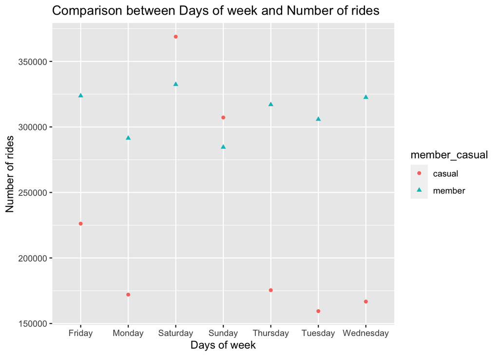

```r
ggplot(data = rides_one_year,aes(x = day_of_week,y=number_of_ride))+
  geom_point(aes(color=member_casual,shape=member_casual))+
  labs(title="Comparison between Days of week and Number of rides",
       x="Days of week",
       y="Number of rides")
```

```r
bike_trip_2020_analysed<- read_csv("~/Desktop/Case study/bike_trips_12_months.csv")
  rides_one_year<-bike_trip_2020_analysed %>%
  group_by(month_of_ride,member_casual)  %>%
  summarize(number_of_ride=n(),.groups = 'drop') %>%
   filter(member_casual=='casual')
```

## Plot between months and number of rides for casual riders

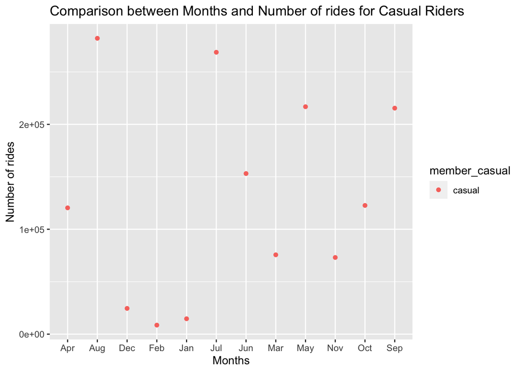

```r
ggplot(data = rides_one_year,aes(x =month_of_ride,y=number_of_ride))+
  geom_point(aes(color=member_casual))+
   labs(title="Comparison between Months and Number of rides for Casual Riders",
       x="Months",
       y="Number of rides")
```

## Plot between months and number of rides for casual and member riders

```r
bike_trip_2020_analysed<- read_csv("~/Desktop/Case study/bike_trips_12_months.csv")
rides_one_year<-bike_trip_2020_analysed %>%
  group_by(month_of_ride,member_casual) %>%
  summarize(number_of_ride=n(),.groups = 'drop')
```

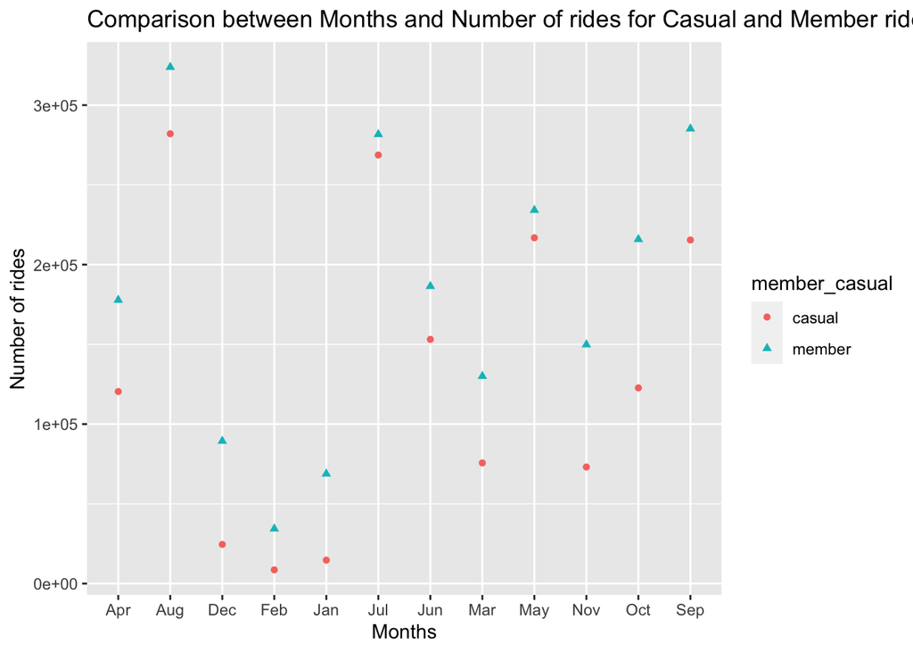

```r
ggplot(data = rides_one_year,aes(x =month_of_ride,y=number_of_ride))+
  geom_point(aes(color=member_casual,shape=member_casual))+
   labs(title="Comparison between Months and Number of rides for Casual and Member riders",
       x="Months",
       y="Number of rides")
```